# PERMUTATION TESTS

30 Mar 2021 (*updated: 2021-03-30)*

## i. Week 10 Focus

- Students Practice on Ch. 8, 9 content.
- Students receive and act on Ch. 7 feedback.
- Read Permutation Tests Ch. 10.
- Discuss Permutation Tests Ch. 10.

## Any questions on Ch.8, 9 HW?

- 8.7 - 8.11
- 9.4 - 9.6

## Today’s plan

1. Open with questions on Ch.10 Problem Set to prime learning.
2. Discuss Ch.10 Permutation Tests, more time on examples
3. Summarize, conclude, revisit Ch.10 Problem prompt discussion / hints time remaining

*Please contribute questions and comments*

## Ch.10 Permutation Tests

- 10.1 Introduction
- 10.2 Tests of Equal Distributions
- 10.3 Multivariate Tests for Equal Distributions
- 10.4 Application: Distance Correlation

## I. Ch.10 HW

- 10.1 - 10.3, 10.6

## II. 10. 1 Introduction

- Permutation tests are powerful nonparametric, computer-intensive procedures.
- Here Rizzo provides a precise way to notate the permutation distribution.
- The idea is to *pool* together the samples.
- Then partition randomly to get a “null” reference distribution, an approximate sampling distribution.

## Example 10.1 Permutation distr. of \(t\)

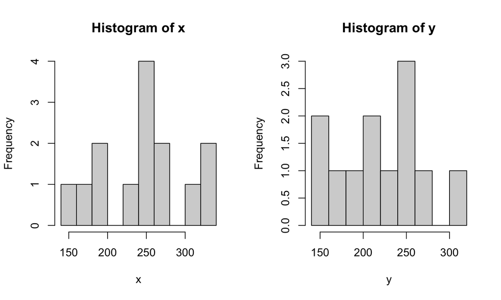

```r
attach(chickwts)
x <- sort(weight[feed == "soybean"])
y <- sort(weight[feed == "linseed"])
detach(chickwts)
par( mfrow = c(1,2) )
hist(x, breaks=8); hist(y, breaks=8)
```

```r
par( mfrow = c(1,1) )
```

## Example 10.1 Permutation distr. of \(t\)

```r
R <- 999              #number of replicates
z <- c(x, y)          #pooled sample
K <- 1:length(z)
reps <- numeric(R)   #storage for replicates
t0 <- t.test(x, y)$statistic
```

## Example 10.1 Permutation distr. of \(t\)

```r
for (i in 1:R) {
    k <- sample(K, size = 14, replace = FALSE)
    x1 <- z[k]
    y1 <- z[-k]      #complement of x1
    reps[i] <- t.test(x1, y1)$statistic
}
(p <- mean(c(t0, reps) >= t0))
```

```
## [1] 0.106
```

## Example 10.1 Permutation distr. of \(t\)

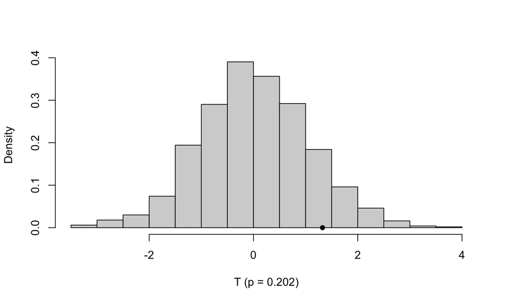

```r
hist(reps, main = "", freq = FALSE, xlab = "T (p = 0.202)",
     breaks = "scott")
points(t0, 0, cex = 1, pch = 16)      #observed T
```

## 10.2 Tests of Equal Distributions

- 2-sample tests for 1D data.
- Example 10.2
- Example 10.3

## Example 10.2 Permutation distr. K-S

```r
R <- 999             #number of replicates
z <- c(x, y)         #pooled sample
K <- 1:26
D <- numeric(R)      #storage for replicates
options(warn = -1)
(D0 <- ks.test(x, y, exact = FALSE)$statistic)
```

```
##        D
## 0.297619
```

## Example 10.2 Permutation distr. K-S

```r
for (i in 1:R) {
    k <- sample(K, size = 14, replace = FALSE)
    x1 <- z[k]
    y1 <- z[-k]      #complement of x1
    D[i] <- ks.test(x1, y1, exact = FALSE)$statistic
}
p <- mean(c(D0, D) >= D0)
options(warn = 0)
p
```

```
## [1] 0.462
```

## Example 10.2 Permutation distr. K-S

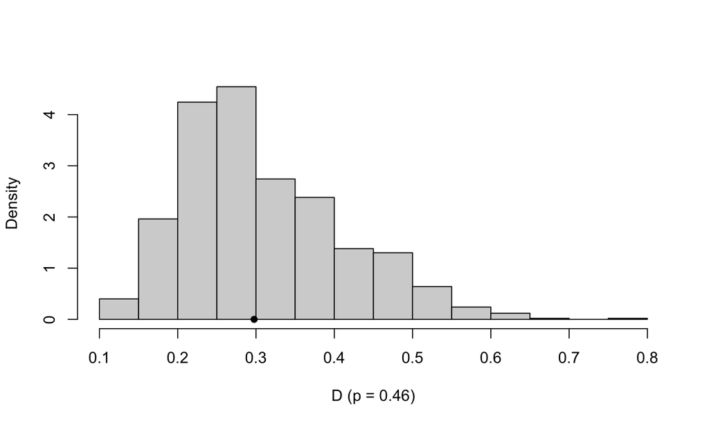

```r
hist(D, main = "", freq = FALSE, xlab = "D (p = 0.46)",
     breaks = "scott")
points(D0, 0, cex = 1, pch = 16)      #observed D
```

## Example 10.3, different groups K-S

```r
attach(chickwts)
x <- sort(weight[feed == "sunflower"])
y <- sort(weight[feed == "linseed"])
detach(chickwts)
summary(cbind(x, y))
```

|  | x | y |
| --- | --- | --- |
|  | Min. :226.0 | Min. :141.0 |
|  | 1st Qu.:312.8 | 1st Qu.:178.0 |
|  | Median :328.0 | Median :221.0 |
|  | Mean :328.9 | Mean :218.8 |
|  | 3rd Qu.:340.2 | 3rd Qu.:257.8 |
|  | Max. :423.0 | Max. :309.0 |

## Example 10.3, different groups K-S

```r
options(warn = -1)
D0 <- ks.test(x, y, exact = FALSE)$statistic
for (i in 1:R) {
    k <- sample(K, size = 14, replace = FALSE)
    x1 <- z[k]
    y1 <- z[-k]      #complement of x1
    D[i] <- ks.test(x1, y1, exact = FALSE)$statistic
}
p <- mean(c(D0, D) >= D0)
options(warn = 0)
p
```

```
## [1] 0.001
```

## Example 10.3, different groups K-S

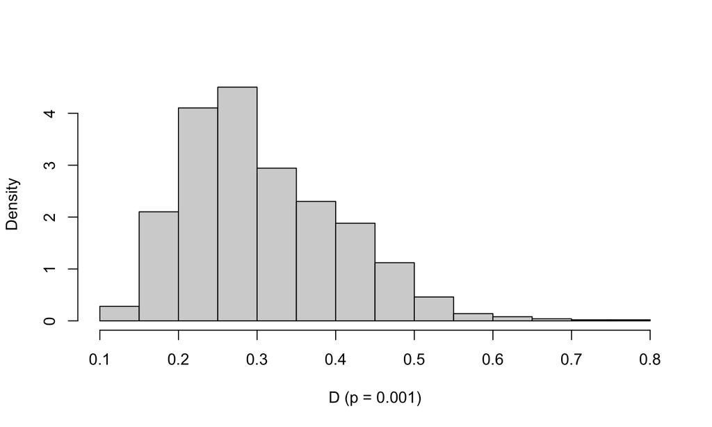

```r
p <- round(p, 3)
hist(D, main = "", freq = FALSE, xlab = paste0("D (p = ",p,")"),
     breaks = "scott")
points(D0, 0, cex = 1, pch = 16)      #observed D
```

## Closing / Ch. 10 Problem set

- Revisit HW Ch.10: 10.1 - 10.3, 10.6
- Questions?
- Students please summarize/ask questions about what we discussed today.